# Лабораторная работа №1

Установка и конфигурация операционной системы на виртуальную машину. Управление версиями

Голощапова Ирина Борисовна

Российский университет дружбы народов, Москва, Россия

9 сентября 2023

# Информация

## Докладчик

- Голощапова Ирина Борисовна
- студентка уч. группы НФИбд-01-20
- Российский университет дружбы народов
- 1032201666@pfur.ru
- https://github.com/ibgoloshchapowa

# Вводная часть

## Объект и предмет исследования

- VirtualBox
- Дистрибутив Rocky
- Github.com

## Цели и задачи

Приобретение практических навыков установки операционной системы на виртуальную машину, настройки минимально необходимых для дальнейшей работы сервисов.

- Установить операционную систему на виртуальную машину
- Изучить идеологию и применение средств контроля версий.
- Освоить умения по работе с git.

# Выполнение работы

## Установка дистрибутива Rocky

1. Кофигурация для новой виртуальной машины

[figure not shown]

Итоговая конфигурация для VB

## Установка дистрибутива Rocky

2. Зашла в настройки созданной новой виртуальной машины и добавила заранее установленный оптический диск:

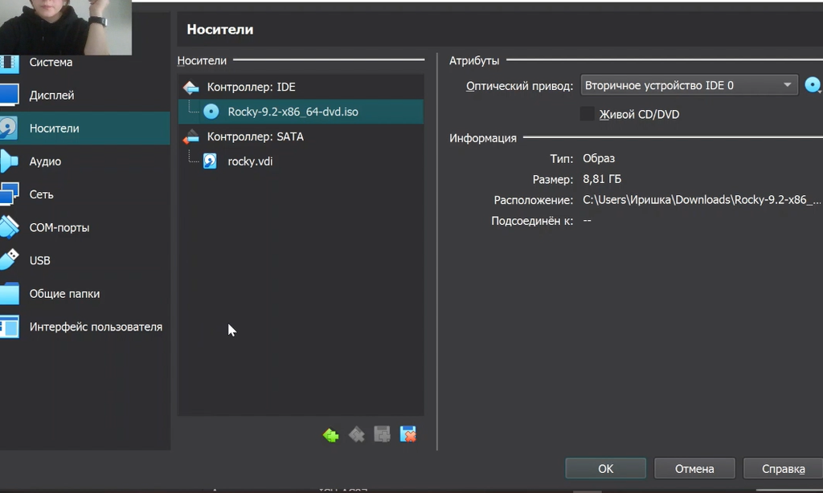

Добавление оптического диска

## Установка дистрибутива Rocky

3. Далее настроила VB согласно методическому материалу, задала пароль root.

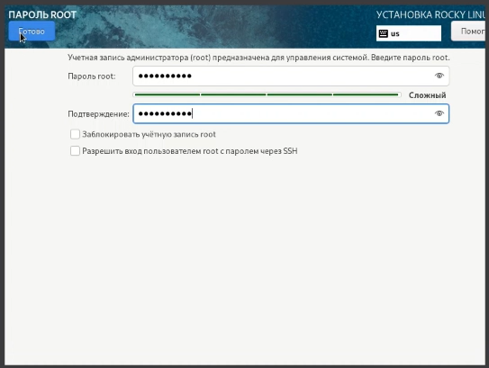

Создание пароля root

## Установка дистрибутива Rocky

4. После настройки перезапустила систему для корректной установки. Указала полное имя и имя пользователя:

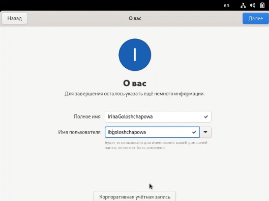

Имя пользователя

## Установка дистрибутива Rocky

5. Подключила образ диска дополнений гостевой ОС:

[figure not shown]

Образ диска дополнений гостевой ОС

## Установка дистрибутива Rocky

6. Проверила на корректность имя хоста:

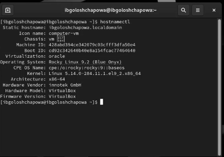

Имя хоста

## Настройка git

1. Задала имя и email владельца репозитория:

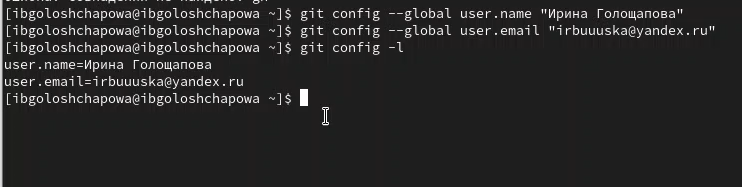

Задание имени и email владельца репозитория

## Настройка git

2. Добавление ssh ключей:

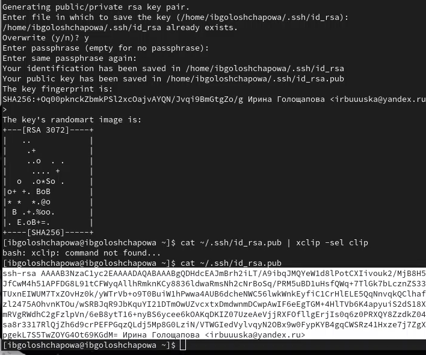

Добавление ssh ключей

## Настройка git

3. Добавление gpg ключей:

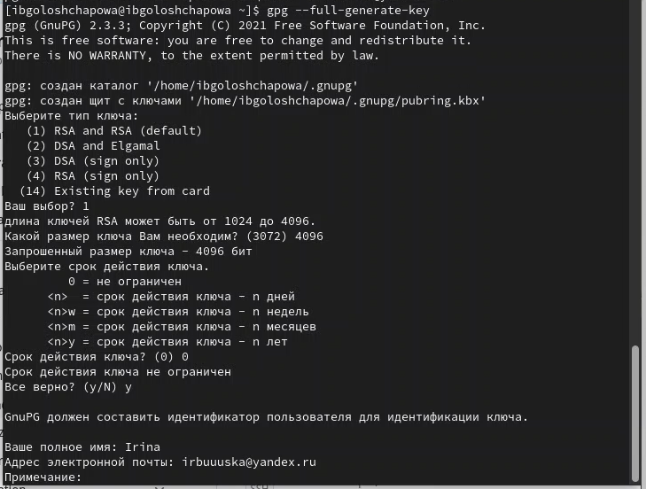

Добавление gpg ключей

## Создание репозитория курса

1. Создала репозиторий согласно шаблону:

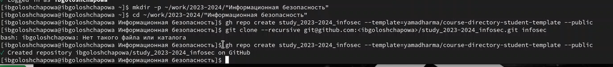

Создание репозитория

## Вывод

В ходе лабораторной работы нам удалось:

- Установить операционную систему на виртуальную машину.
- Изучить идеологию и применение средств контроля версий.
- Освоить умения по работе с git.